# Lecture 5: Point Level Models - Variograms

# Class Intro

## Intro Questions

- What is point referenced data?
- How do we predict the response at unobserved locations?
- For Today:
  - What is a variogram?
  - How is a variogram useful?
  - How is EDA used for point referenced data?

# Elements of Geostatistical models: continued…

## Stationarity

- Assume the spatial process, $\boldsymbol{Y}(\boldsymbol{s})$ has a mean, $\boldsymbol{\mu}(\boldsymbol{s})$, and that the variance of $\boldsymbol{Y}(\boldsymbol{s})$ exists everywhere.
- The process is **strictly stationary** if: for any $n \geq 1$, any set of $n$ sites $\{\boldsymbol{s}_1, \dots, \boldsymbol{s}_n\}$ and any $\boldsymbol{h} \in \mathcal{R}^r$ (typically r =2), the distribution of $(\boldsymbol{Y}(\boldsymbol{s}_1). \dots, \boldsymbol{Y}(\boldsymbol{s+h}_n))$ is the same as $\boldsymbol{Y}(\boldsymbol{s+h}_1)$

## Strict Stationarity

Is this strictly stationary?

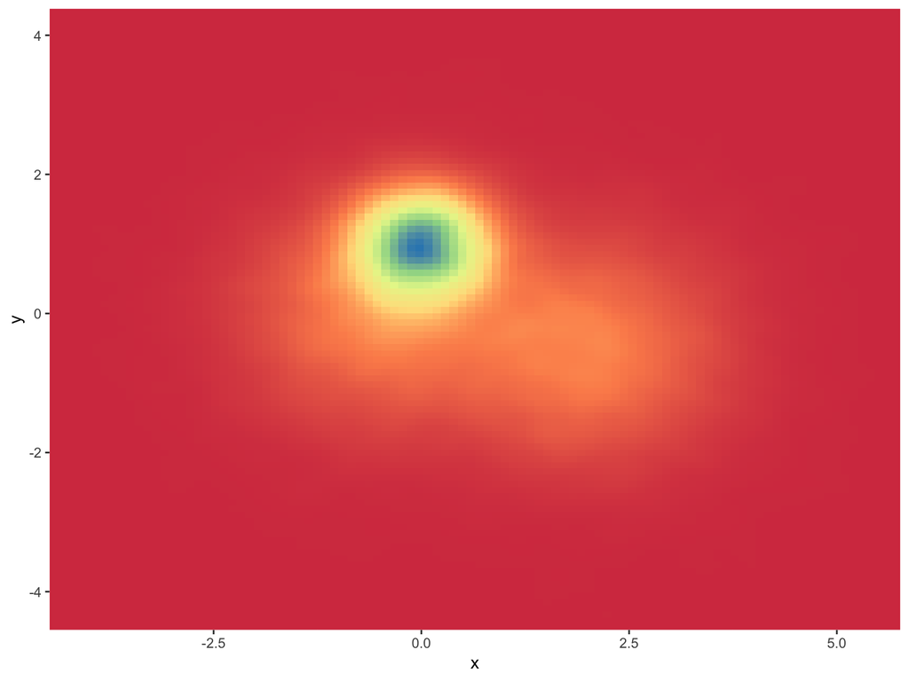

## Weak Stationarity

- Weak stationarity, or second-order stationarity of a spatial process, requires a constant mean and covariance that is a function of $\boldsymbol{h}$, $Cov(\boldsymbol{Y}(\boldsymbol{s}),\boldsymbol{Y}(\boldsymbol{s +h})) = C(\boldsymbol{h}),$ where $C(\boldsymbol{h})$ is a covariance function that only requires the separation vector $\boldsymbol{h}.$
- Typically with spatial models, the process is assumed to be mean zero as covariates explain the mean structure. So second-order stationarity is primarily focused on the covariance structure.

## Weak Stationarity

Is this weakly stationary?

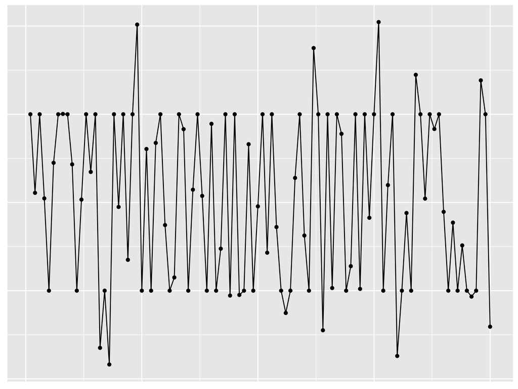

## Intrinsic Stationarity

- A third kind of stationarity, known as intrinsic stationarity, describes the behavior of differences in the spatial process, rather than the data.
- Intrinsic stationarity assumes $E[\boldsymbol{Y}(\boldsymbol{s + h}) -\boldsymbol{Y}(\boldsymbol{s}) ] =0$ then define
  $$E[\boldsymbol{Y}(\boldsymbol{s + h}) - \boldsymbol{Y}(\boldsymbol{s})]^2 = Var(\boldsymbol{Y}(\boldsymbol{s + h}) - \boldsymbol{Y}(\boldsymbol{s})) = 2 \gamma(\boldsymbol{h}),$$
  which only works, and satisfies intrinsic stationarity, if the equation only depends on $\boldsymbol{h}$.

## Variograms

- Intrinsic stationary justifies the use of variograms $2\gamma( \boldsymbol{h})$
- Variograms are often used to visualize spatial patterns:
  - If the distance between points is small, the variogram is expected to be small
  - As the distance between points increases, the variogram increases
- There is a mathematical link between the covariance function $C(\boldsymbol{h})$ and the variogram $2\gamma(\boldsymbol{h})$.

## Isotropy

- If the variogram $2\gamma(\boldsymbol{h})$ depends only on the length of $\boldsymbol{h}$, $||\boldsymbol{h}||,$ and not the direction, then the variogram is isotropic.
- If the direction of $\boldsymbol{h}$ impacts the variogram, then the variogram is anisotropic.

# More about Variograms

## Variogram to the Covariance Function

$$\begin{eqnarray*}
2 \gamma (\boldsymbol{h}) &=& Var(\boldsymbol{Y}(\boldsymbol{s+h}) - \boldsymbol{Y}(\boldsymbol{s}))\\
&=& Var(\boldsymbol{Y}(\boldsymbol{s+h})) + Var(\boldsymbol{Y}(\boldsymbol{s})) - 2 Cov(Var(\boldsymbol{Y}(\boldsymbol{s+h}),\boldsymbol{Y}(\boldsymbol{s})))\\
&=&C(\boldsymbol{0}) + C(\boldsymbol{0}) - 2C(\boldsymbol{h})\\
&=& 2 \left[C(\boldsymbol{0}) - C(\boldsymbol{h})\right]
\end{eqnarray*}$$

- Given $C()$, the variogram can easily be recovered
- Going the other way, $2\gamma() \rightarrow C()$, requires additional assumptions

## Linear semivariogram

$$\gamma(d)=
\begin{cases}
\tau^2 + \sigma^2d \; \; \text{if } d > 0\\
0 \; \; \text{otherwise}
\end{cases}$$

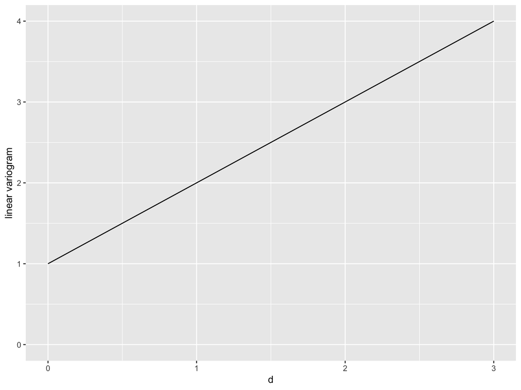

## Nugget, sill, partial-sill, and range

- Nugget is defined as $\gamma(d): \; d \rightarrow 0_+$
- Sill is defined as $\gamma(d): \; d \rightarrow \infty$
- Partial sill is defined as the $\text{sill} - \text{nugget}$
- Range is defined as the first point where $\gamma(d)$ reaches the sill. Note the Range is often defined as $R =\frac{1}{\phi}$, but confusingly both $R$ and $\phi$ are sometimes referred to as the range. More properly, $\phi$ is called the decay parameter.

## Spherical semivariogram: Exercise

$$\gamma(d)=
\begin{cases}
\tau^2 + \sigma^2 \; \; \text{if } d \geq 1/ \phi\\
\tau^2 + \sigma^2\left[\frac{3\phi d}{2} - \frac{1}{2} (\phi d)^3 \right]\\
0 \; \; \text{otherwise}
\end{cases}$$

- Sketch, or generate in R, a spherical semivariogram
- On this figure label the nugget, sill, partial sill, and range.

## Spherical semivariogram: Solution

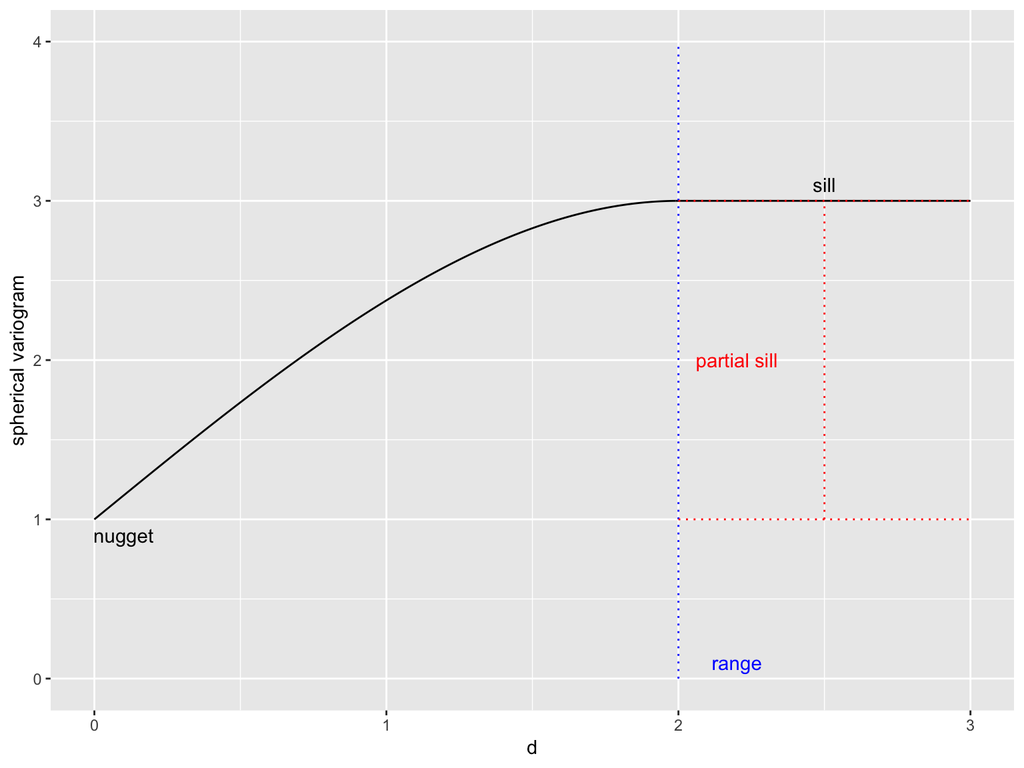

# More Variograms

## Exponential

- We saw the exponential covariance earlier in class, what is the mathematical form?
- $$C(d)=
  \begin{cases}
  \tau^2 + \sigma^2 \; \; \text{if } d = 0\\
  \sigma^2 \exp(-\phi d) \; \; \text{if } d > 0
  \end{cases}$$
- The variogram is
  $$\gamma(d)=
  \begin{cases}
  \tau^2 + \sigma^2(1 - \exp(-\phi d)) \; \; \text{if } d > 0\\
  0 \; \; \text{otherwise}
  \end{cases}$$

## Exponential Semivariogram: Exercise

- Plot the exponential semivariogram
- Identify and interpret: the nugget, range, and sill. How are they similar or different from the spherical semivariogram?

## Exponential Semivariogram: Solution

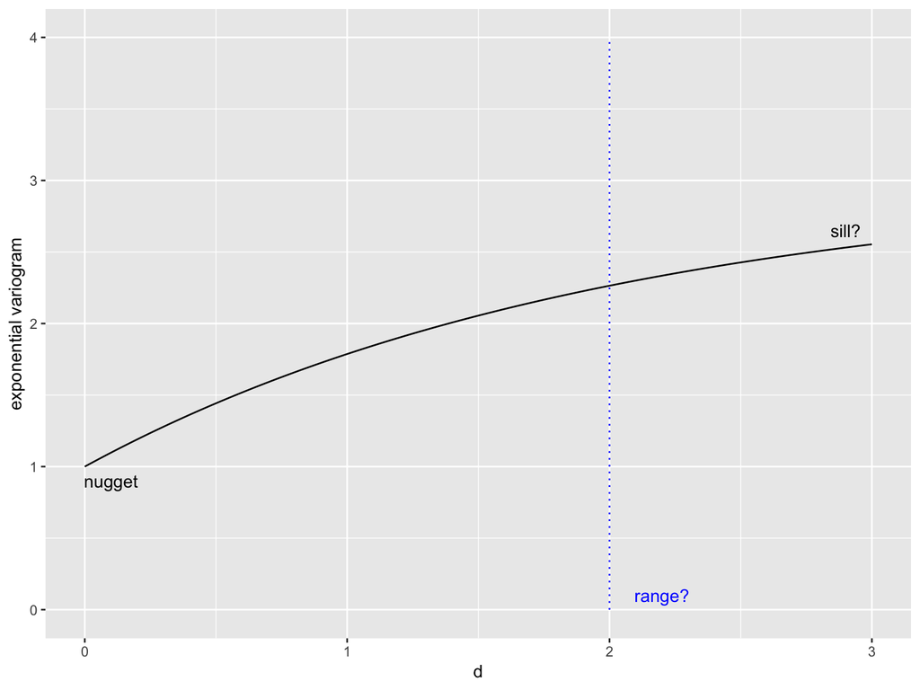

## Exponential Semivariogram: Solution 2

- The sill is only reached asymptotically when
  $$\lim_{d\rightarrow \infty} exp(-\phi * d) \rightarrow 0$$
- Thus, the range, defined as distance where semivariogram reaches the sill is $\infty$
- The *effective range* is defined as the distance where there is *effectively* no spatial structure. Generally this is determined when the correlation is .05.
- $$\begin{eqnarray*}
  \exp(-d_o \phi) &=&.05 \\
  d_0 \phi &=& - \log(.05) \\
  d_0 &\approx& \frac{3}{\phi}
  \end{eqnarray*}$$

## Exponential Semivariogram: Solution 3

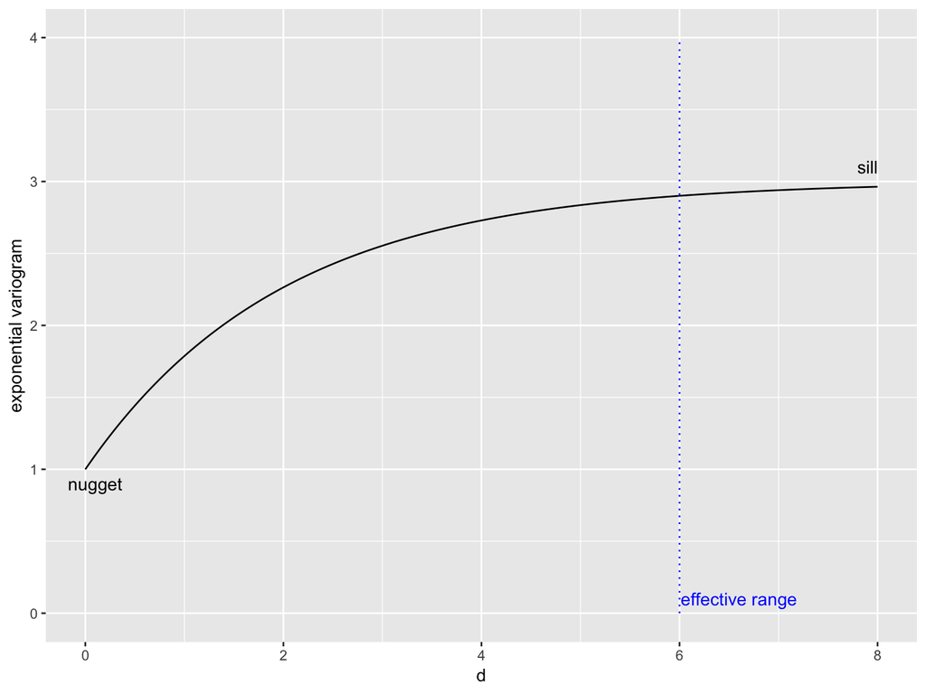

## More Semivariograms: Equations

- Gaussian:
  $$\gamma(d)=
  \begin{cases}
  \tau^2 + \sigma^2(1 - \exp(-\phi^2 d^2)) \; \; \text{if } d > 0\\
  0 \; \; \text{otherwise}
  \end{cases}$$
- Powered Exponential:
  $$\gamma(d)=
  \begin{cases}
  \tau^2 + \sigma^2(1 - \exp(-|\phi d|^p)) \; \; \text{if } d > 0\\
  0 \; \; \text{otherwise}
  \end{cases}$$
- Mat$\acute{\text{e}}$rn:
  $$\gamma(d)=
  \begin{cases}
  \tau^2 + \sigma^2\left[1 - \frac{(2\sqrt{\nu}d \phi)^\nu}{2^{\nu-1}\Gamma(\nu)} K_\nu (2 \sqrt{\nu} d \phi)\right] \; \; \text{if } d > 0\\
  0 \; \; \text{otherwise}
  \end{cases},$$
  where $K_\nu$ is a modified Bessel function and $\Gamma()$ is a Gamma function.

# Variogram Creation

## Variogram Creation: How?

| x | y | copper |
| --- | --- | --- |
| 181072 | 333611 | 85 |
| 181025 | 333558 | 81 |
| 181165 | 333537 | 68 |
| 181298 | 333484 | 81 |
| 181307 | 333330 | 48 |
| 181390 | 333260 | 61 |
| 181165 | 333370 | 31 |
| 181027 | 333363 | 29 |
| 181060 | 333231 | 37 |
| 181232 | 333168 | 24 |
| 181191 | 333115 | 25 |
| 181032 | 333031 | 25 |
| 180874 | 333339 | 93 |
| 180969 | 333252 | 31 |
| 181011 | 333161 | 27 |

## Variogram Creation: Steps

1. Calculate distances between sampling locations
2. Choose grid for distance calculations
3. Calculate empirical semivariogram
   $$\hat{\gamma}(d_k) = \frac{1}{2N(d_k)} \sum_{\boldsymbol{s}_i,\boldsymbol{s}_i, \in N(d_k)}\left[ \boldsymbol{Y}(\boldsymbol{s}_i) - \boldsymbol{Y}(\boldsymbol{s}_j) \right]^2,$$
   where
   $$N(d_k) = \{(\boldsymbol{s}_i,\boldsymbol{s}_j): ||\boldsymbol{s}_i -\boldsymbol{s}_j|| \in I_k\}$$
   and $I_k$ is the $k^{th}$ interval.
4. Plot the semivariogram

## Variogram Creation: R function

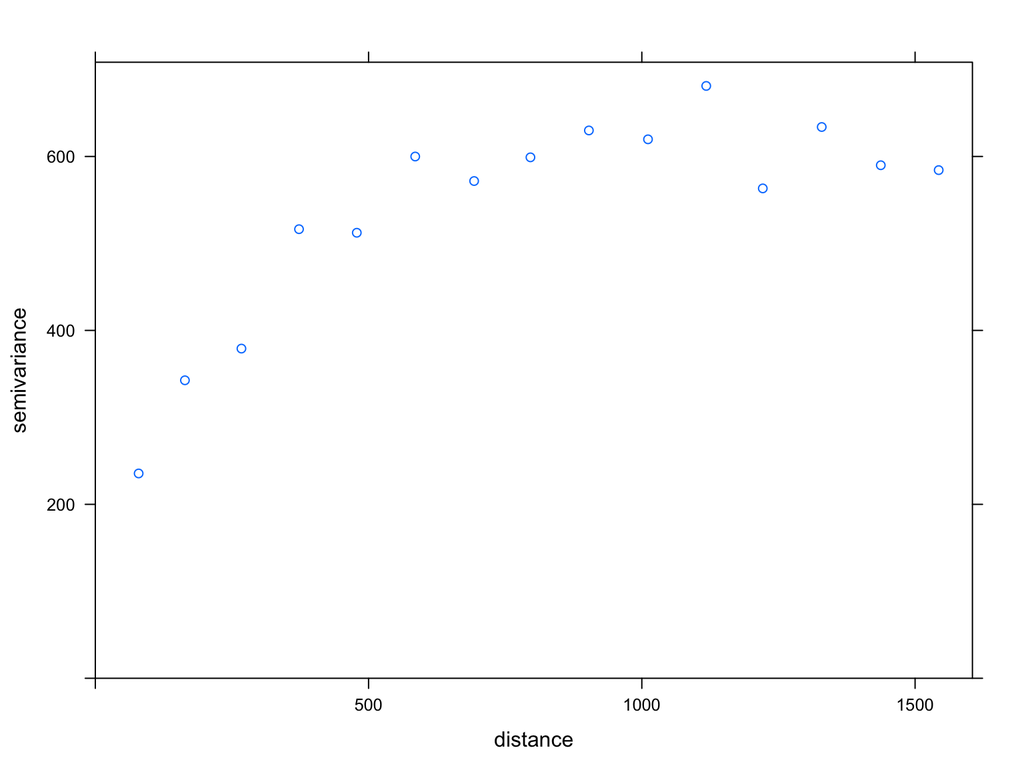

## Variogram Creation: How - Step 1

Calculate Distances between sampling locations

```r
dist(meuse.small)
```

[output not shown]

[output cut: 3975 more lines]

[output not shown]

```r
dist.mat <- dist(meuse.small %>% select(x,y))
```

## Variogram Creation: How - Step 2

Choose grid for distance calculations

```r
cutoff <- max(dist.mat) / 3 # default maximum distance
num.bins <-  15
bin.width <- cutoff / 15
```

## Variogram Creation: How - Step 3

Calculate empirical semivariogram

```
## # A tibble: 15 x 2
##      bin emp.sv
##    <dbl>  <dbl>
##  1     1   236.
##  2     2   347.
##  3     3   348.
##  4     4   488.
##  5     5   499.
##  6     6   577.
##  7     7   553.
##  8     8   623.
##  9     9   600.
## 10    10   665.
## 11    11   603.
## 12    12   673.
## 13    13   557.
## 14    14   643.
## 15    15   574.
```

## Variogram Creation: How - Step 4

Plot empirical semivariogram

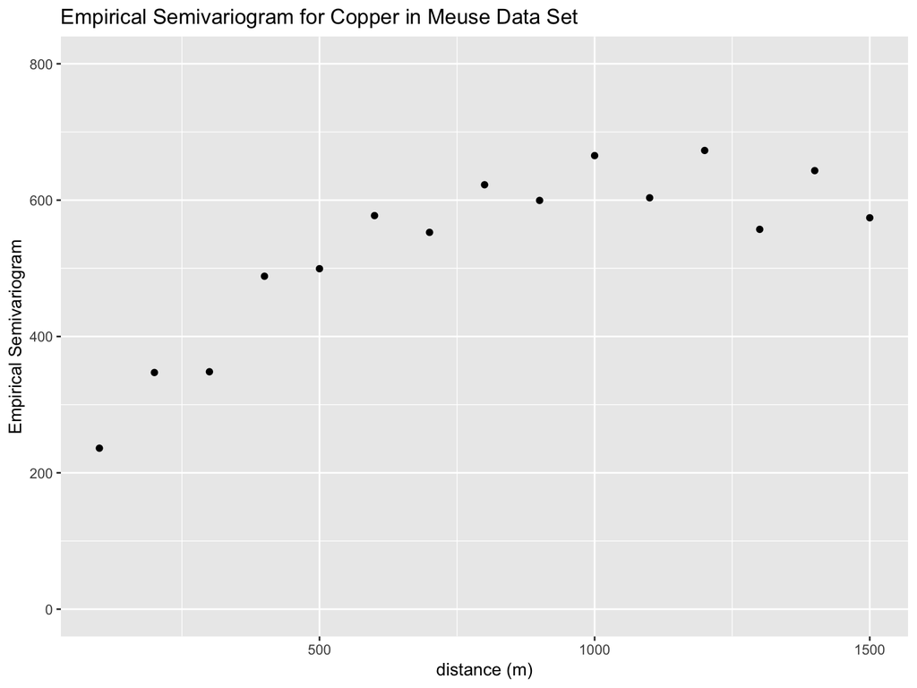

## Variogram Fitting

Now given this empirical semivariogram, how to we choose a semivariogram (and associated covariance structure) and estimate the parameters in that function??

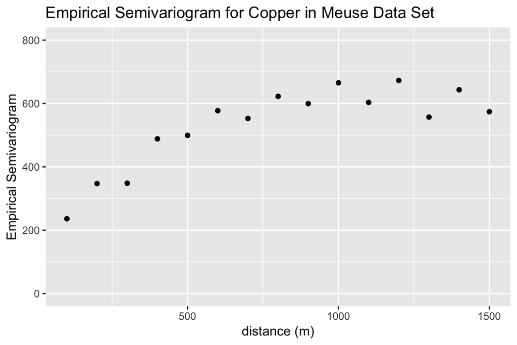